# DTS-SQL Project

5009小组瓦力z

2024-04-17

# 准备步骤

1. 假设项目已经在HPC上。
2. 在`./DTS-SQL`下新建空文件夹training和validation
3. 将[spider数据集](https://yale-lily.github.io/spider)下载解压到`./DTS-SQL`目录，并将spider文件夹重命名为**datasets**。

# 数据准备：finetuning_dataset_creator.py

## 修改文件

1. 在finetuning_dataset_creator.py的头部位置加入下述代码，让python工作路径定位到`./DTS-SQL`文件夹。

```python
import os
os.chdir('/hpc2hdd/home/tzou317/DTS-SQL')  # 我的hpc工作路径
```

2. 修改

```python
# 原版：
def load_spider_dev_set():
    df = pd.read_json("spider-syn/dev.json")
    return df
```

```python
# 修改后：
def load_spider_dev_set():
    df = pd.read_json("datasets/dev.json")
    return df
```

`spider-syn/dev.json`应该指的是Spider-SYN数据集的验证集，我们暂时只处理Spider数据集，其验证集路径为`datasets/dev.json`。（Spider数据集本身就分好了有训练集、验证集和测试集）

3. 修改

```python
# 原版
for index, row in tqdm(df.iterrows(), total=len(df)):
    db_id = row["db_id"]
    question = row["SpiderSynQuestion"]  # 改这里
    query = row["query"]
```

```python
# 修改后
for index, row in tqdm(df.iterrows(), total=len(df)):
    db_id = row["db_id"]
    question = row["question"]  # 改这里
    query = row["query"]
```

因为修改了验证集，所以部分文件列名要修改

4. 修改

```python
df.to_csv("validation/filtered_spider_syn_dataset.csv", index=False)
```

把最后一行代码文件末尾加上.csv。

## 运行

运行finetuning_dataset_creator.py会多出5个.csv文件

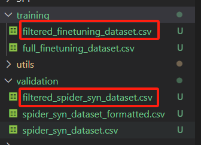

# 第二步大模型微调：sql_generation_finetuning.ipynb

这个文件是对第二步大模型的fine-tuning。这里我们直接假设已经有了精简化的DB信息（实际上应该由第一步大模型生成），然后对第二步大模型进行微调，再推理和验证结果。这样可以得到一个EX（Execution Accuracy）效果上限。

## 修改文件

1. 在文件头部加入和之前一样的工作路径

```python
import os
os.chdir('/hpc2hdd/home/tzou317/DTS-SQL')
```

再顺手命令行指定一下huggingface镜像

```bash
export HF_ENDPOINT=https://hf-mirror.com
```

2. 修改

```python
# 原版：
data_files = {"train": "full_finetuning_dataset.csv", "validation": "validation_dataset_formatted.csv"}
dataset = load_dataset('csv', data_files=data_files)
```

```python
# 修改后：
data_files = {"train": "training/filtered_finetuning_dataset.csv", "validation": "validation/filtered_spider_syn_dataset.csv"}
dataset = load_dataset('csv', data_files=data_files)

print(len(dataset['train']), len(dataset['validation']))  # 训练集8412条，验证集1034条
```

`filtered_finetuning_dataset.csv`和`filtered_spider_syn_dataset.csv`文件分别含有第二步大模型的输入：问题（question）、精简后的数据库信息（filtered_database_schema）。

3. 修改

```python
# 原版：
def formatting_prompts_func(training_dataset):
  output_texts = []
  for i in range(len(training_dataset['question'])):
    question = training_dataset['question'][i]
    query = training_dataset['query'][i]
    database_schema = training_dataset['database_schema'][i]  # 改这里
```

```python
# 修改后：
def formatting_prompts_func(training_dataset):
  output_texts = []
  for i in range(len(training_dataset['question'])):
    question = training_dataset['question'][i]
    query = training_dataset['query'][i]
    database_schema = training_dataset['filtered_database_schema'][i]
```

## 运行

运行时间大概1.5h？

运行后的输出结果是微调好的lora层，存放于`SFT/final_checkpoint`中。我把SFT文件名修改成了peft_models。

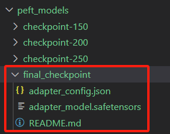

# 第二步大模型推理：sql_generation_inference.ipynb

修改下述代码，可实现对spider验证集的推理。

```python
# 原版
df = pd.read_csv("validation_dataset.csv")  # 改这里
results = []
for index, row in tqdm(df.iterrows(), total=len(df)):
  question = row['question']
  query = row['query']
  database_schema = row['database_schema']  # 改这里
  db_id = row['db_id']
```

```python
# 修改后
df = pd.read_csv("test/validation_dataset.csv")
results = []
for index, row in tqdm(df.iterrows(), total=len(df)):
  question = row['question']
  query = row['query']
  database_schema = row['filtered_database_schema']
  db_id = row['db_id']
```

第一个修改位置原代码文件为`validation/filtered_spider_syn_dataset`，这里只是换了个路径，然后重命名了一下

第二个修改位置表示输入精简化后的数据库信息（`filtered_database_schema`）到prompt中去。而原版的`database_schema`表示输入所有的数据库信息到prompt中去。

# Evaluation Metrics

作者文件会输出`Gold.txt`和`Predicted.txt`，将两个文件下载到本地，将后缀改成`.sql`。

**[test-suit-sql-eval](https://github.com/taoyds/test-suite-sql-eval)**:

Git bash:

```bash
cd path/to/store/test-suite-sql-eval
git clone https://github.com/taoyds/test-suite-sql-eval.git
```

Anaconda Prompt:

```bash
activate env_nl2sql
cd path/to/store/test-suite-sql-eval
python evaluation.py --gold D:/NL2SQL/Data/spider/dev_gold.sql --pred D:/NL2SQL/python_workspace/NL2SQL_data_preparation/experiment6/test/test_pred.sql --db D:/NL2SQL/Data/spider/database --table D:/NL2SQL/Data/spider/tables.json  --etype all
```

`--gold` 后面是spider真实SQL标签的路径。上面是我的本地spider验证集的真实标签路径，也可以是作者代码生成的`Glod.sql`路径，两者应该是一样的。

`--pred` 后面是`Predicted.sql`的路径。

`--db` 后面是spider数据集的数据库database文件夹路径

`--table` 后面是spider数据集的table.json文件路径

直接运行就会出结果，应该不会再报错了。

2024-3-19日运行spider验证集结果：

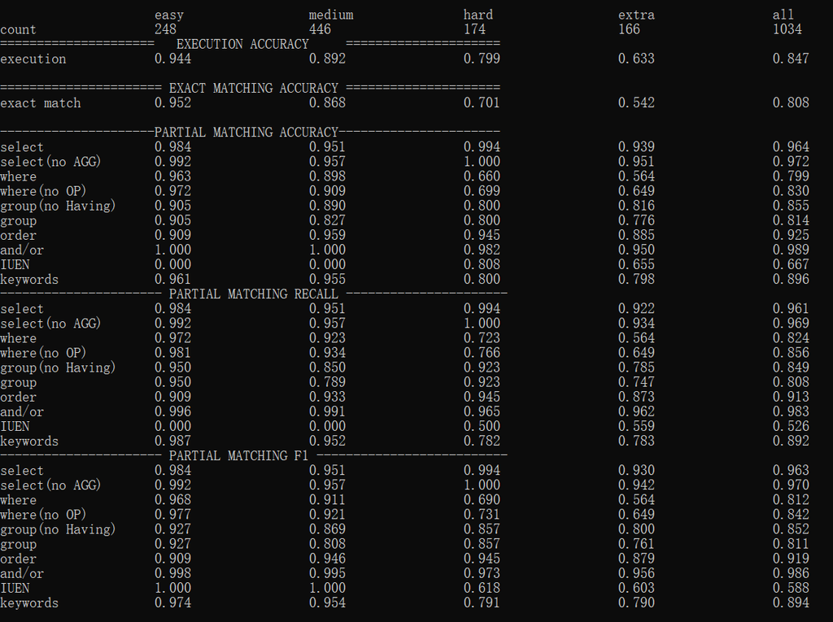

但是并没有达到他论文中的90.3%：

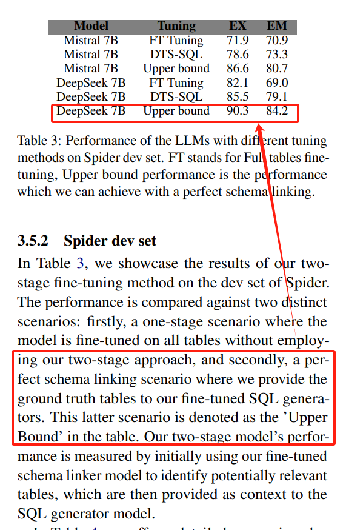

# Experiment Details

[output not shown]

## to_table

### experiment11

```python
lora_r = 64
lora_alpha = 16
lora_dropout = 0.1
output_dir = "nl2sql/experiment11/to_table/peft_model"
num_train_epochs = 1
bf16 = True
overwrite_output_dir = True
per_device_train_batch_size = 1
per_device_eval_batch_size = 1
gradient_accumulation_steps = 16
gradient_checkpointing = True
evaluation_strategy = "steps"
learning_rate = 5e-5
weight_decay = 0.01
lr_scheduler_type = "cosine"
warmup_ratio = 0.01
max_grad_norm = 0.3
group_by_length = True
auto_find_batch_size = False
save_steps = 50
logging_steps = 10
load_best_model_at_end= False
packing = False
save_total_limit=3
neftune_noise_alpha=5
report_to="wandb"
max_seq_length = 2500 #set based on the maximum number of queries
```

Prompt1’s format:

```bash
`Given the following SQL tables, your job is to determine the tables that the question is referring to. Please format the answer in {"tables": [entities]}

CREATE TABLE stadium (
Stadium_ID,
Location,
Name,
Capacity,
Highest,
Lowest,
Average);

CREATE TABLE singer (
Singer_ID,
Name,
Country,
Song_Name,
Song_release_year,
Age,
Is_male);

CREATE TABLE concert (
concert_ID,
concert_Name,
Theme,
Stadium_ID,
Year);

CREATE TABLE singer_in_concert (
concert_ID,
Singer_ID);

###
Question:
What are the number of concerts that occurred in the stadium with the largest capacity ?`
```

Outputs1’s format:

`{"tables": ['concert', 'stadium']}`

$$outputs1\_evalution = 0.946$$

train_loss: 0.025, eval_loss: 0.158

# Full experiment details

experiment11:

$outputs1\_evalution=0.946$